# Estimating ART Forgiveness in Real-World Data

A Causal Framework for Adherence-Response

2026-03-25

### Estimating ART Forgiveness in Real-World Data

**A Causal Framework for Adherence-Response**

*From adherence thresholds to intervention-defined causal curves*

## Scientific motivation: what is “forgiveness”?

The assessment and analysis of adherence to ART is **critical to examining treatment benefits** among people with HIV.

- Adherence is **on the causal pathway** from regimen initiation to most treatment outcomes
- **Choice of adherence measure** reflects assumptions about the relationship with outcome
- Comparing regimens requires disentangling pharmacologic effects from adherence behavior

**The practical question:** > At what level of suboptimal adherence does a regimen still maintain virologic suppression — and does this differ across regimens?

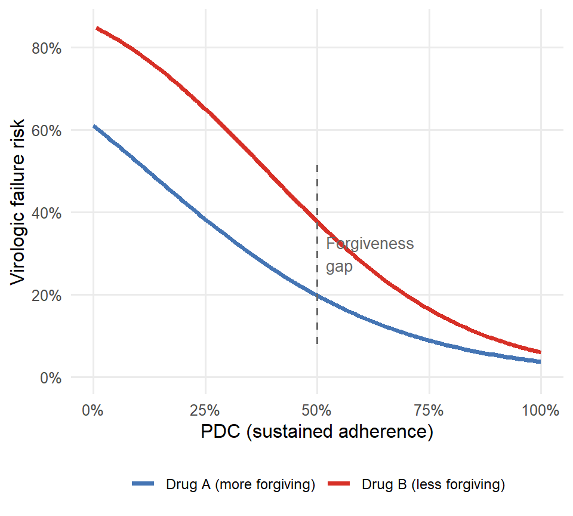

Figure 1

## Adherence is a post-treatment, time-varying variable

**The feedback loop:**

- **Worsening health $\to$ reduced adherence:** side effects, complications lower the probability of taking medication
- **Reduced adherence $\to$ worse virologic control:** subtherapeutic drug levels allow viral replication
- **Worse viral control $\to$ further health deterioration:** clinical status worsens
- **Updated clinical status influences next-period adherence:** the cycle continues

. . .

**Consequence:** Conditioning on observed adherence in a regression does two incompatible things simultaneously:

> It attempts to *adjust for confounding* by health status, while also *blocking the adherence effect* through that same health pathway.

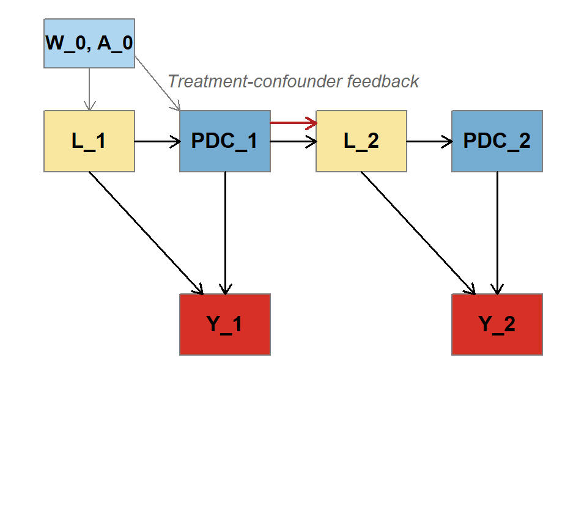

Figure 2

$L_t$ is a **time-varying confounder** of $\text{PDC}_t \to Y_t$ that is **itself affected by prior** $\text{PDC}_{t-1}$

Standard regression cannot fix this. G-computation can.

## V4 Simplified simulation setup

**Cohort design:**

- $n$ = 5,000 patients, 4 quarterly (90-day) blocks, 12 months follow-up
- Drug A vs. Drug B: fixed at baseline, randomised 1:1
- **One baseline covariate:** $W_0 \sim N(0,1)$ (clinical severity)
- **One time-varying confounder:** $L_t$ (health status, continuous)

**Intentionally simplified:**

- No informative monitoring (all patients observed)
- No treatment switching
- Optional censoring (off for validation)
- Continuous block-level PDC generated directly in 90-day increments
- Explicit treatment-confounder feedback: $\text{PDC}_{t-1} \to L_t \to \text{PDC}_t$

**Key DGP properties:**

| Feature | Value |
| --- | --- |
| Mean PDC (Drug A) | 0.68 |
| Mean PDC (Drug B) | 0.74 |
| Cumulative failure | 18.5% |

**Forgiveness mechanism:**

Drug A’s failure hazard includes a protective interaction at low adherence:

$\gamma_{A \times P} = -1.2$ (Drug A $\times$ poor adherence)

- At high PDC: both drugs perform similarly
- At low PDC: Drug A has substantially lower failure risk
- Drugs have different adherence distributions (Drug A lower)

**Why simplified?** GLM-based LTMLE is approximately unbiased here because the DGP is low-dimensional and parametric. This isolates the methodological lessons from model specification concerns.

## Oracle forgiveness curves

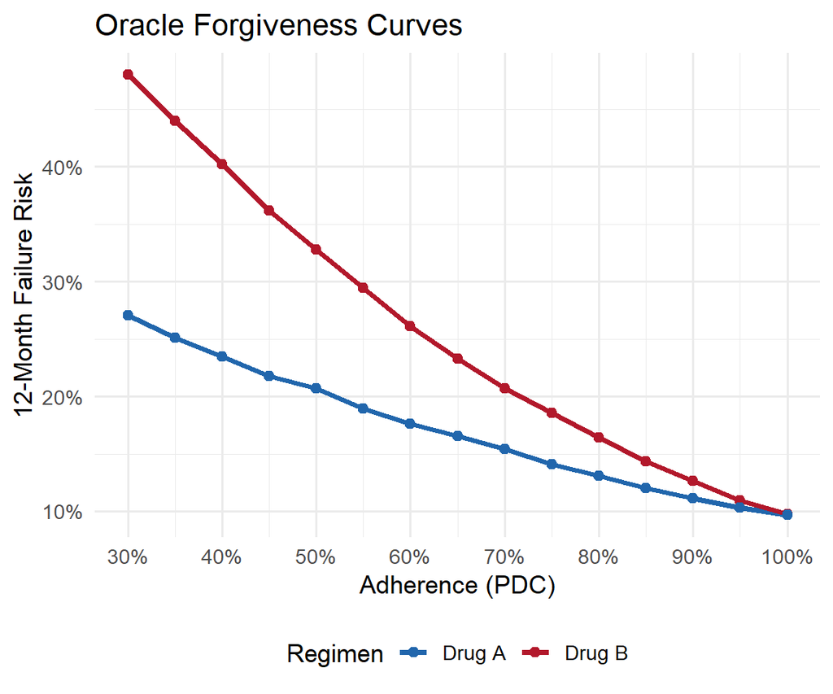

Figure 3

Table 1: Oracle risks at selected PDC levels

[output not shown]

- At PDC $\geq$ 85%: Drug A and Drug B perform similarly
- At PDC $\leq$ 50%: Drug A failure risk is dramatically lower
- The **forgiveness gap** widens as adherence declines

## Naive adherence-stratified analyses are biased

**What stratification does:** Divide patients by observed mean PDC, compare outcomes within strata

**What this produces:**

|  | High PDC group | Low PDC group |
| --- | --- | --- |
| Who they are | Healthier | Sicker |
| Virologic trajectory | Already suppressed | Already struggling |
| Apparent effect | Large benefit | Large harm |
| True source | **Selection** | **Selection** |

**The result:** the naive forgiveness curve is **too steep** — it overstates how much adherence matters because it compares different types of patients

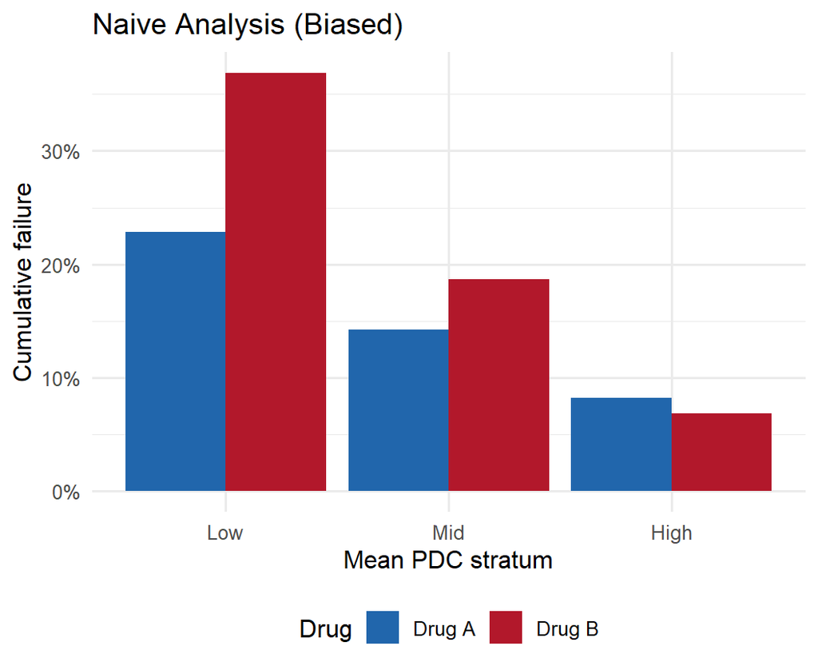

Figure 4

## Positivity: when static estimation breaks down

**The problem:** Forcing *all* patients to the *same* PDC category across *all* 4 blocks is rare in observed data

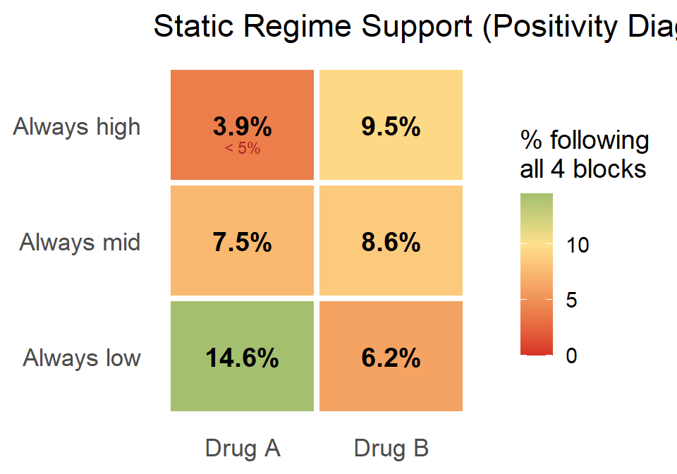

Figure 5

**Two types of positivity failure:**

**L-TMLE:** wide CIs, honest about uncertainty — conservative but valid

**Static LMTP:** density-ratio weights can collapse — potentially invalid inference

. . .

**Solution:** Use **feasible shift interventions** (LMTP) that stay within observed support, rather than forcing implausible static regimes.

$d(\text{PDC}_t) = \min(\text{PDC}_t + 0.10,\; 1.0)$

Every patient’s shifted PDC is a plausible value they could have achieved.

## L-TMLE results: static adherence regimes

Table 2: LTMLE estimates vs oracle (GLM nuisance, clean setting)

|  | Drug | Category | LTMLE | SE | Oracle | Bias | Conv |
| --- | --- | --- | --- | --- | --- | --- | --- |
| 4 | Drug B | high | 0.0925 | 0.0177 | 0.1186 | -0.0261 | TRUE |
| 5 | Drug B | low | 0.3549 | 0.0389 | 0.4730 | -0.1181 | TRUE |
| 6 | Drug B | mid | 0.1903 | 0.0216 | 0.1862 | 0.0040 | TRUE |
| 1 | Drug A | high | 0.1224 | 0.0269 | 0.1104 | 0.0121 | TRUE |
| 2 | Drug A | low | 0.2318 | 0.0211 | 0.2615 | -0.0297 | TRUE |
| 3 | Drug A | mid | 0.1258 | 0.0192 | 0.1419 | -0.0161 | TRUE |

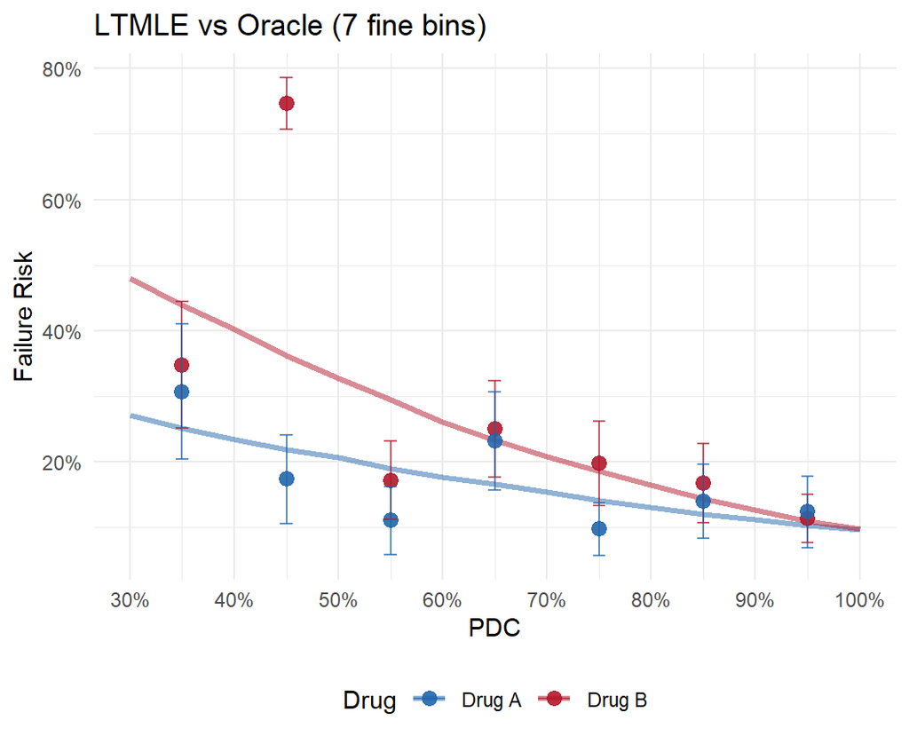

Figure 6

## LMTP shift: feasible adherence improvement

Table 3: LMTP: natural risk and +10% PDC shift vs oracle

|  | Drug | Natural | Nat.Oracle | Nat.Bias | +10% | Shift Oracle | Shift Bias |
| --- | --- | --- | --- | --- | --- | --- | --- |
| Drug B | Drug B | 0.2001 | 0.2068 | -0.0068 | 0.1146 | 0.1637 | -0.0491 |
| Drug A | Drug A | 0.1686 | 0.1676 | 0.0010 | 0.1161 | 0.1437 | -0.0277 |

- Shift estimand: $d(\text{PDC}_t) = \min(\text{PDC}_t + 0.10, 1)$
- Stays within observed support — stable inference
- Policy-relevant: “what would an adherence-support program achieve?”

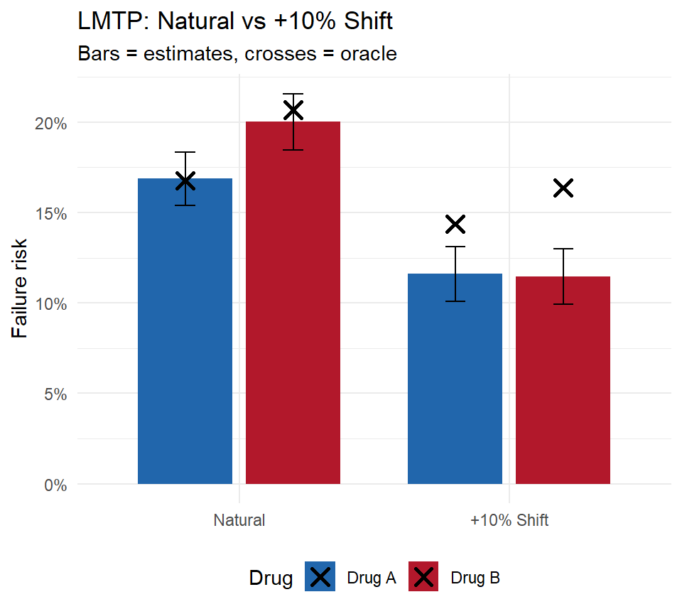

Figure 7

## Comparing regimens under matched adherence

**The question:** *If both drugs operated under the same adherence distribution, which produces lower failure risk?*

**Implementation:** quantile-map Drug A’s adherence to match Drug B’s distribution, then estimate risk for each drug under Drug B-like adherence.

Table 4: Drug comparison under matched (Drug B) adherence

| Estimand | Estimate | Oracle | SE | Bias |
| --- | --- | --- | --- | --- |
| Drug B (own adherence) | 0.2001 | 0.2092 | 0.0079 | -0.0091 |
| Drug A (under Drug B adherence) | 0.1359 | 0.1507 | 0.0079 | -0.0149 |
| Risk difference (A - B) | -0.0642 | -0.0585 | 0.0112 | -0.0057 |

Under the same adherence distribution, Drug A has **lower** failure risk than Drug B.

This isolates the **pharmacological forgiveness effect** from differential adherence patterns between regimens.

The risk difference (-0.064) represents the causal drug effect at a common, realistic adherence distribution.

## Bias comparison across methods

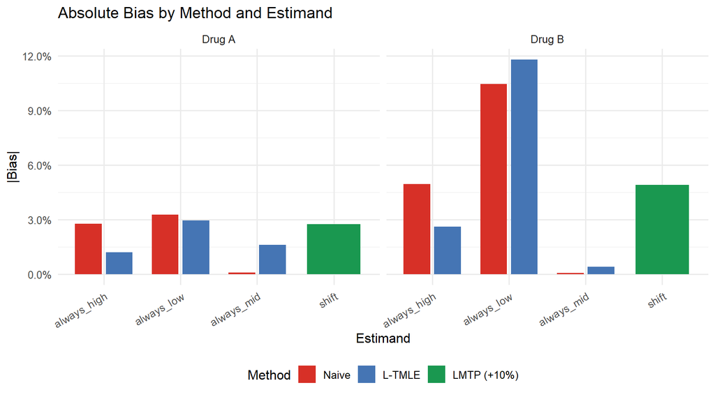

Figure 8

## Takeaways

**If you want to separate regimen properties from patient behavior, you need the right estimand.**

# Appendix

## Appendix: V4 DGP parameters

**Adherence process** (logit-normal AR(1)):

| Parameter | Value | Role |
| --- | --- | --- |
| $\alpha_0$ | 1.3 | Intercept |
| $\alpha_A$ | -0.35 | Drug A effect |
| $\alpha_W$ | -0.2 | Severity effect |
| $\alpha_L$ | -0.3 | Health status effect |
| $\rho$ | 0.45 | AR persistence |
| $\sigma_u$ | 0.5 | Random intercept SD |
| $\sigma_e$ | 0.65 | Innovation SD |

**Failure hazard:**

| Parameter | Value | Role |
| --- | --- | --- |
| $\gamma_0$ | -3.8 | Intercept |
| $\gamma_L$ | 0.5 | Health status effect |
| $\gamma_W$ | 0.3 | Severity effect |
| $\gamma_P$ | 2.5 | Poor adherence effect |
| $\gamma_A$ | 0 | Drug A main effect |
| $\gamma_{AP}$ | -1.2 | Drug A forgiveness |

$\gamma_{AP} < 0$: Drug A is *more forgiving* at low adherence